# 基于nCov2019程序包的 疫情区域特征分析

2020/4/16

## 展示内容

1.`nCov2019`程序包的介绍

2.数据可视化-`nCov2019` Map

3.合成控制法介绍

4.合成控制法案例及R实现

## 1. `nCov2019`程序包的介绍

- `nCov2019`的来源
- `nCov2019`的安装
- 最新数据的获取
- 历史数据的获取

### `nCov2019`的来源：

作者：Guangchuang YU（创建者和维护者）  
《用于研究COVID-19冠状病毒爆发的开源分析工具》  
(发表于《COVID-19 SARS-CoV-2 preprints from medRxiv and bioRxiv》）  
https://github.com/GuangchuangYu/nCov2019.

该程序包用于获取有关冠状病毒爆发的流行病学数据，其中包含详细的实时统计信息，也包含中国详细的城市级数据和世界范围内的国家级数据。数据将从2020年1月13日起每天自动更新。  
数据中的变量包括国家、省、城市、确诊人数、疑似人数、治愈人数、死亡人数等。

### `nCov2019`的安装：

利用`remotes`包直接从GitHub安装。

```r
library('remotes')
remotes::install_github("GuangchuangYu/nCov2019", dependencies = TRUE)
```

利用`devtools`包安装

```r
install.packages("devtools")
devtools::install_github("GuangchuangYu/nCov2019")
```

离线安装  
从GitHub上下载zip压缩文件，在本地R Studio上进行安装

```r
devtools::install_local("nCov2019-master.zip")
```

### 最新数据的获取

要查询最新数据，可以使用get_nCov2019()。默认情况下，语言设置会根据用户的系统环境自动设置为中文或英文。也可以使用参数lang = ’zh’或lang = ’en’显式设置语言。

```r
>library('nCov2019')
>x <- get_nCov2019(lang = 'en')
>x
China (total confirmed cases): 83817
last update: 2020-04-17 08:22:14
```

获取最新中国疫情数据

```r
>head(summary(x))
  confirm suspect dead heal importedCase deadRate healRate  date
1      41       0    1    0         0         2.4      0.0 01.13
2      41       0    1    0         0         2.4      0.0 01.14
3      41       0    2    5         0         4.9     12.2 01.15
4      45       0    2    8         0         4.4     17.8 01.16
5      62       0    2   12         0         3.2     19.4 01.17
6     198       0    3   17         0         1.5      8.6 01.18
```

获取中国的省级疫情数据

```r
>head(x[])
            name  confirm suspect dead deadRate  heal healRate
1      Hong Kong     1017       0    4     0.39   485    47.69
2   Heilongjiang      872       0   13     1.49   471    54.01
3         Taiwan      395       0    6     1.52   155    39.24
4          Hubei    67803       0 3222     4.75 64435    95.03
5       Shanghai      628       0    7     1.11   489    77.87
6 Inner Mongolia      193       0    1     0.52    94    48.70
```

要获取更详细的市级数据，只需指定省名。

```r
>head(x['Shanxi'])
      name  confirm suspect dead deadRate heal healRate
1  Taiyuan       64       0    0     0.00    2     3.12
2 Jinzhong       37       0    0     0.00   37   100.00
3   Datong       12       0    0     0.00   12   100.00
4 Yuncheng       19       0    0     0.00   19   100.00
5  Xinzhou        7       0    0     0.00    7   100.00
6 Jincheng       10       0    0     0.00   10   100.00
```

通过使用x[‘global’]，获取全球数据。

```r
>head(x['global'])
            name confirm suspect  dead deadRate   heal healRate
1          China   83817      63  3352     4.00  78558    93.73
2         France  147863       0 17188    11.62  31470    21.28
3  United States  143071       0  2513     1.76   4856     3.39
4 United Kingdom  104145       0 13759    13.21    375     0.36
5          Italy   97689       0 10779    11.03  13030    13.34
6          Spain   85195       0  7340     8.62  14709    17.27
```

### 可视化

- 累计确诊案例条形图

```r
d <- summary(x)
library(ggplot2)
ggplot(d,
       aes(as.Date(date, "%m.%d"), as.numeric(confirm))) +
  geom_col(fill = 'firebrick') +
  theme_minimal(base_size = 14) +
  xlab(NULL) + ylab(NULL) +
  scale_x_date(date_labels = "%Y/%m/%d") +
  labs(caption = paste("accessed date:", time(x)))
```

[output not shown]

### 历史数据的获取

有三个数据库可以获取历史数据。  
第一个是从GitHub存储库中收集和组织的，用户将默认访问或使用load_nCov2019(source = ‘github’)来获取。  
第二个是从中文网站丁香园获得的，用户可以使用load_nCov2019(source = ‘dxy’)来访问。  
第三个是从中国国家卫生委员会获得的，用户可以通过使用load_nCov2019(source = ‘cnnhc’)来获取 。  
这些数据的形式基本相同，但是默认数据源具有更全面的全局历史信息，并且还包含较旧的历史数据。用户可以比较和切换来自不同来源的数据。

```r
>library('nCov2019')
>y <- load_nCov2019(lang = 'en')
>y
nCov2019 historical data
last update: 2020-04-15
```

获取中国的省级历史数据：

```r
>head(summary(y))
        time country province cum_confirm cum_heal cum_dead suspected
1 2019-12-01   China    Hubei           1        0        0         0
2 2019-12-02   China    Hubei           1        0        0         0
3 2019-12-03   China    Hubei           1        0        0         0
4 2019-12-04   China    Hubei           1        0        0         0
5 2019-12-05   China    Hubei           1        0        0         0
6 2019-12-06   China    Hubei           1        0        0         0
```

获取中国所有城市的历史数据

```r
>head(y[])
        time country province  city cum_confirm cum_heal cum_dead
1 2019-12-01   China    Hubei Wuhan           1        0        0
2 2019-12-02   China    Hubei Wuhan           1        0        0
3 2019-12-03   China    Hubei Wuhan           1        0        0
4 2019-12-04   China    Hubei Wuhan           1        0        0
5 2019-12-05   China    Hubei Wuhan           1        0        0
6 2019-12-06   China    Hubei Wuhan           1        0        0
```

指定省名来获取相应的历史数据

```r
>head(y['Shanxi'])
          time country province     city cum_confirm cum_heal
125 2020-01-22   China   Shanxi  Taiyuan           1        0
211 2020-01-23   China   Shanxi  Taiyuan           1        0
374 2020-01-24   China   Shanxi  Taiyuan           2        0
375 2020-01-24   China   Shanxi   Datong           1        0
376 2020-01-24   China   Shanxi Changzhi           1        0
377 2020-01-24   China   Shanxi Yuncheng           2        0
```

’global’参数获取全部历史数据

```r
>y <- load_nCov2019(lang = 'en', source='github')
>d <- y['global']
>tail(d)
           time      country cum_confirm cum_heal cum_dead
8550 2020-04-15        Yemen           1        0        0
8551 2020-04-15      Mayotte         217       69        3
8552 2020-04-15 South Africa        2415      410       27
8553 2020-04-15       Zambia          48       30        2
8554 2020-04-15     Zimbabwe          18        1        3
8555 2020-04-15      Namibia          16        3        0
```

### 可视化

- 山西省确诊人数曲线图

```r
library('nCov2019')
library('ggrepel')
library('ggplot2')
y <- load_nCov2019(lang = 'en')
d <- y['Shanxi']
ggplot(d, aes(time, as.numeric(cum_confirm),
              group = city, color = city)) +
  geom_point() + geom_line() +
  geom_label_repel(aes(label = city),
                   data = d[d$time == time(y), ], hjust = 1) +
  theme_minimal(base_size = 14) + theme(legend.position = 'none') +
  scale_x_date(date_labels = "%Y-%m-%d") + xlab(NULL) + ylab(NULL) +
  theme(axis.text.x = element_text(hjust = 1)) +
  labs(title = "Growth curve of confirms in Shanxi Province, China")
```

[output not shown]

- 世界十大国家的疫情趋势曲线

```r
require(nCov2019)
x = load_nCov2019()
d = x['global']
head(d)

require(dplyr)
n <- d %>% filter(time == time(x)) %>%
  top_n(10, cum_confirm) %>%
  arrange(desc(cum_confirm)) %>%
  pull(country)
n
```

```r
require(ggplot2)
require(ggrepel)
ggplot(filter(d, country %in% n),
       aes(time, cum_confirm, color=country)) +
  geom_line() +
  geom_text_repel(aes(label=country),
                  function(d) d[d$time == time(x),]) +
  theme_minimal(base_size=14) +
  theme(legend.position = "none") +
  xlab(NULL) + ylab(NULL)
```

[output not shown]

## 2.nCov2019 Map

- Open-source analytics tools for studying the COVID-19 coronavirus outbreak
- 用于研究COVID-19冠状病毒爆发的开源分析工具
- https://www.medrxiv.org/

## 主要内容

- 全球疫情地图
- 中国疫情地图
- 省市疫情地图
- 每日疫情变化图

## 全球疫情地图

```r
library(remotes)
remotes::install_github("GuangchuangYu/nCov2019", dependencies = TRUE)
```

```r
library(png)
library(maps)
library(nCov2019)
x = get_nCov2019()#此时的环境默认为中文
```

- 绘制全球疫情地图

```r
plot(x)
```

[output not shown]

- 中国显示的疫情状况是否过于严重？
- 为了更细致的展示中国疫情状况，将中国疫情数据细分为各个省份
- 调用地图数据

```r
remotes::install_github("GuangchuangYu/chinamap")
```

```r
library(chinamap)
cn = get_map_china()
```

- 绘制全球疫情地图（包含中国各省份数据）

```r
plot(x, chinamap=cn)
```

[output not shown]

- 绘制外国疫情地图

```r
x = get_nCov2019(lang = 'en')#此时应设置为英文
plot(x, region='Japan')
```

[output not shown]

```r
x = get_nCov2019()
```

## 中国疫情地图

- 绘制中国疫情地图

```r
plot(x, region='china', chinamap=cn)#默认数据为连续型数据
```

[output not shown]

- 展示离散型数据，添加`continuous_scale=FALSE`
- 渲染不同的颜色，添加`palette=''`
- 载入历史数据，添加`date=''`

```r
plot(x, region='china', chinamap=cn,
     continuous_scale=FALSE,palette='Greens',date='2020-02-15')
```

[output not shown]

## 省市疫情地图

- 调用市界地图数据（china-city-map.rar）
- https://github.com/moruizhe/Data

```r
m = sf::st_read(".../市界.shp")
```

- 绘制省市疫情地图

```r
x = get_nCov2019()#此时的环境默认为中文
plot(x, region='湖北', chinamap=m)
```

[output not shown]

- 展示多个省市疫情地图

```r
plot(x, region=c('广东','福建'),chinamap=m)
```

[output not shown]

## magick

- 制作动图：`from`和`to`
- magick 包: 在R中进行高级图片处理
- 功能：
  - 格式转换：从一种格式转换成图像到另一个（例如 PNG 转 JPEG）
  - 变换：缩放，旋转，裁剪，翻转或修剪图像
  - 图像识别：描述的格式和图像性能
  - …
- 调用函数

```r
library(magick)
library(chinamap)
```

## 每日疫情变化图

- 绘制疫情变化图(全国)

```r
cn = get_map_china()
y <- load_nCov2019()#载入nCov2019数据
d <- c(paste0("2020-01-", 24:31),
       paste0("2020-02-", 1:10))#确定数据框
img <- image_graph(600, 450, res = 96)#打开图形设备
out <- lapply(d, function(date)
{
  p <- plot(y, region='china', chinamap=cn, date=date,
            label=FALSE)#绘制每一"帧"图像
  print(p)
})
dev.off()#关闭图形设备

animation <- image_animate(img, fps = 2)#fps控制放映速度
image_write(animation, "ncov2019.gif")
```

[figure not shown]

- 绘制疫情变化图(省)
- 添加`m = sf::st_read(".../市界.shp")`
- 修改
  - `region='湖北'`
  - `chinamap=m`

[figure not shown]

## 动图存储平台

- https://giphy.com/

[figure not shown]

## 3.合成控制法介绍

- 随机对照实验
- 政策评估框架
- 准自然实验方法
- SCM提出背景
- SCM的操作步骤
- 合成组构造思路
- 安慰剂检验介绍
- SCM的优劣势

## 随机对照实验（Randomized Controlled Trial）

医学领域进行随机对照实验过程中，研究人员随机将实验样本分为处理组和对照组。

- 处理组（treatment group）：实施某种医疗或药物干预；
- 对照组（control group）：不实施干预，其他医疗环境一样。
- 干预效应：处理组的效果与对照组的效果的差异。

## 政策评估框架（准自然实验）

政策评估的必要性：经济学家常要评估某政策或时间的经济社会效应，政策可能实施于某些国家或地区,为此，常使用“鲁宾的反事实框架”（Rubin’s counterfactual framework）。

鲁宾的反事实框架（Rubin’s counterfactual framework）：假想该地区未受政策干预将会怎样，并与事实受到干预的实际数据进行对比，二者之差即为“处理效应”(treatment effect)。

常用的解决方法：寻找适当的控制组(control group)，即在各个方面都与受干预地区相似但却未受干预的其他地区，以作为处理组（即受到干预的地区）的反事实替身（counterfactuals）。

## 准自然试验方法

- 双重差分法（DID)——构造出反映政策效果的双重差分统计量
- 倾向得分匹配法(PSM)–找到相似的控制组和干预组
- 断点回归法(RD)——公共政策因果效应评估
- 合成控制法(SCM)——构造合成控制地区
- 回归控制法(RCM)——利用不同个体的截面相关，构造受处理单位的反事实结果

## SCM提出背景

合成控制法的使用场景类似于双重差分法，但是不同之处在于干预组只有一个个体。这个个体往往是一个城市、地区或者国家。

- 比较案例研究(comparative case studies):要考察仅在A市实施的某政策效果，自然会想到以之相近的B市作为控制地区；但B市毕竟与A市不完全相同。或可用其他城市（C市、D市）构成A市的控制组，比较B市、C市、D市与A市在政策实施前后的差别。
- 缺陷：选择对照地区存在主观随意性(ambiguity),B市、C市、D市与A市也不完全相同。
- 合成控制法(Synthetic control method):以上述例子来说，虽然无法找到A市的最佳控制地区，但通常可对若干城市进行适当的线性组合，以构造一个更为优秀的“合成控制地区” (synthetic control region)，并将“真实A市”与“合成A市”进行对比，故名“合成控制法”。

## SCM的操作步骤

1、筛选合适的控制组，确定合理的预测变量；

2、拟合一个适宜的反事实合成组；

3、对比合成组与处理组的差异以评估政策冲击的影响；

4、安慰剂检验

## 合成组构造思路

假定只有一个地区（i=1）受政策干预的影响，并且有J个没有政策干预地区（\(i=2，…，J+1\)），\(P_{it}^N\)和\(P_{it}^Y\)分别是地区i在没有政策干预下和有政策干预下的变量取值，政策在\(T_0+1（1≤T_0＜T)\)开始实施，研究样本的地区为\(i=1，…，J+1\)，样本时间为\(t=1，…，T\)。 根据假定，试点地区1的政策效果为：

\(α_{1t}=P_{1t}^Y- P_{1t}^N （t=T_0+1, …, T）\)

其中，\(P_{1t}^Y\)可以被观测，\(P_{1t}^N\)不能被观测。 为了估计\(P_{1t}^N\)\(（t=T_0+1, …, T）\)，利用合成控制法构建一个合成的对照地区：

\(\hat{P}_{1t}^N\) =\(\sum_{i=2}^{j+1}\)\(W_i^t P_{it}^N\)

其中，\(W_i^*\)是地区\(i\)的权重，满足\(W_i^*≥0\)和\(\sum_{i=2}^{j+1}\)\(W_i^* =1\)。

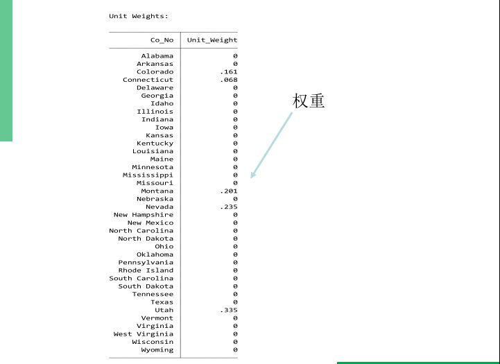

各地区最优权重

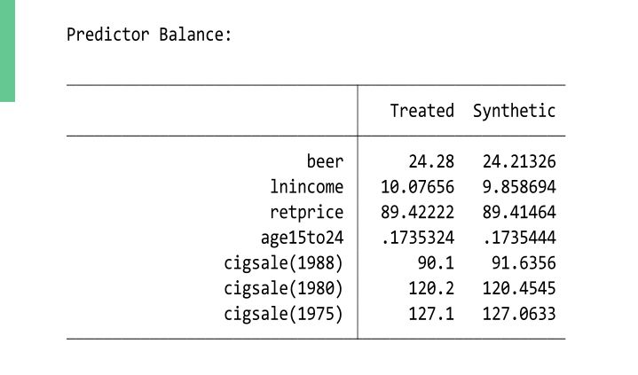

真实加州和合成加州的预测变量

Abadie（2010）证明，在一定的正则条件下，如果合成控制的\(w*\)能完全的复制处理地区的经济特征与干预前的结果变量，则当干预前期数趋向无穷大时，合成控制估计量是渐进无偏的。

反之，如果合成控制\(w^*\)无法很好地复制处理地区的经济特征与干预前的结果变量，则合成控制估计量将是渐近有偏的。因此，在使用合成控制法时，一个重要的模型设定检验就是，考察合成控制的经济特征与干预前的结果变量是否与处理地区足够接近。

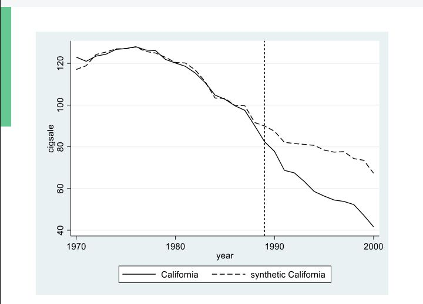

人均香烟消费量对比

## 安慰剂检验

“安慰剂”（placebo）一词来自医学上的随机实验，比如要检验某种新药的疗效。此时，可将参加实验的人群随机分为两组，其中一组为实验组，服用真药；而另一组为控制组，服用安慰剂（比如，无用的糖丸），并且不让参与者知道自己服用的究竟是真药还是安慰剂，以避免由于主观心理作用而影响实验效果，称为“安慰剂效应”（placebo effect） 安慰剂是一种附加实证检验的思路，并不存在一个具体的特定的操作方法。下面介绍一种常用思路。

以合成控制法为例，通俗一点讲，就是将控制组的每个地区作为处理组，假设这些地区在相同时期也接受了政策干预，按照合成控制法的步骤进行验证，如果政策效果与之前的实验有显著差异，则排除了随机因素影响，认为是政策干预产生的效果。

## SCM的优势

- 作为一种非参数的方法，是对传统的双重查分法的拓展。
- 通过数据驱动确定权重，减少了主观选择的误差。
- 通过对多个控制对象加权来模拟目标政策实施前的情况，可以清晰地反映每个控制对象对“反事实”事件的贡献。

## SCM的劣势

- 需要的面板数据比较苛刻，要求干预前的期数达到一定规模；另外，如果政策冲击的效应需要一段时间才会显现（滞后效应），则也要求干预后的期数足够大。
- 不适用于微观数据。
- 对比传统回归, 该方法有一个显著缺点:无法得到有意性推断，它无法输出我们常用的P值T值等判断指标, 只能通过安慰性检验等手段侧面手段来佐证。

## 4.合成控制法案例及R实现

- 相关案例：恐怖主义冲突对经济的影响
  - 背景介绍
  - 思路介绍
- 合成控制法在R语言中的实现
  - 需要的R程序包
  - 数据及建模过程
  - 安慰剂检验
- 小结及展望

## 案例背景介绍

- 在七十年代恐怖主义活动开始之初（1975），巴斯克地区是西班牙最富有的地区之一，人均国内生产总值（在17个地区中）排名**第三位**。
- 在二十世纪九十年代末，经过30年的恐怖和政治冲突，巴斯克地区人均GDP下降到**第六位**。
- 在此期间，巴斯克恐怖组织ETA开展的恐怖活动导致近800人死亡。巴斯克地区的企业家和公司已经成为暴力和勒索的具体目标（包括暗杀，抢劫和索要赎金的绑架）。
- 政治不稳定被认为对经济繁荣有很大的不利影响。

## 案例具体思路

- Abadie and Gardeazabal（2003）研究了1975年后恐怖主义冲突对巴斯克地区经济效应的影响
- 结合其他西班牙地区，使用其**线性组合**构建了一个“合成巴斯克”地区，并使其经济特征与恐怖主义冲突爆发前的巴斯克地区尽可能相似
- 比较“合成巴斯克”与真实巴斯克的人均GDP演化

## 需要的R程序包

- `Synth`程序包：比较案例研究中用于实现合成控制法的R包
- `numDeriv`程序包：提供了用于计算准确的数值一阶和二阶导数的方法
- `kernlab`程序包：用于分类，回归，聚类，新颖性检测，分位数回归和降维等机器学习方法
- `optimx`程序包：扩展的最优化函数，基于导数的算法收敛到全局最小值

## 案例数据介绍

- 处理组：受到恐怖活动冲击的巴斯克地区
- 控制组：其余16个未受到冲击的西班牙地区
- 潜在假定：恐怖活动仅影响巴斯克地区
- 结果变量：1955-1997年（冲突发生前后）巴斯克地区和西班牙其他地区的人均GDP： `gdpcap`
- 预测变量（13个）：
  - 投资率（投资占总产出的百分比）： `invest`
  - 产业结构（各产业所占份额）： `sec.agriculture`、`sec.energy`、`sec.industry`、`sec.construction`、`sec.services.venta`、`sec.services.nonventa`
  - 人力资本： `school.illit`、`school.prim`、`school.med`、`school.high`、`school.post.high`
  - 人口密度： `popdens`

## 案例变量导入

```r
>library("Synth")
>data("basque")
>basque[85:89, 1:4]
   regionno regionname year   gdpcap
85        2  Andalucia 1996 5.995930
86        2  Andalucia 1997 6.300986
87        3     Aragon 1955 2.288775
88        3     Aragon 1956 2.445159
89        3     Aragon 1957 2.603399
```

## 案例变量生成

```r
dataprep.out <- dataprep(
  foo = basque,
  predictors = c("school.illit", "school.prim", "school.med",
  "school.high", "school.post.high", "invest"),
  predictors.op = "mean", time.predictors.prior = 1964:1969,
  special.predictors = list(
    list("gdpcap", 1960:1969 , "mean"),
    list("sec.agriculture", seq(1961, 1969, 2), "mean"),
    list("sec.energy", seq(1961, 1969, 2), "mean"),
    list("sec.industry", seq(1961, 1969, 2), "mean"),
    list("sec.construction", seq(1961, 1969, 2), "mean"),
    list("sec.services.venta", seq(1961, 1969, 2), "mean"),
    list("sec.services.nonventa", seq(1961, 1969, 2), "mean"),
    list("popdens", 1969, "mean") ),
  dependent = "gdpcap",
  unit.variable = "regionno",
  unit.names.variable = "regionname",
  time.variable = "year",
  treatment.identifier = 17, controls.identifier = c(2:16, 18),
  time.optimize.ssr = 1960:1969, time.plot = 1955:1997)
```

## 最小化均方预测误差

```r
>  synth.out <- synth(data.prep.obj = dataprep.out, method = "BFGS")
```

```r
X1, X0, Z1, Z0 all come directly from dataprep object.

****************
 searching for synthetic control unit

****************
****************
****************

MSPE (LOSS V): 0.008864606

solution.v:
 0.02773094 1.194e-07    1.60609e-05 0.0007163836 1.486e-07
 0.002423908 0.0587055   0.2651997   0.02851006   0.291276
 0.007994382 0.004053188 0.009398579 0.303975

solution.w:
 2.53e-08  4.63e-08 6.44e-08  2.81e-08  3.37e-08 4.844e-07
 4.2e-08   4.69e-08 0.8508145 9.75e-08  3.2e-08  5.54e-08
 0.1491843 4.86e-08  9.89e-08 1.162e-07
```

## 最优权重的估计结果

```r
> synth.tables <- synth.tab(dataprep.res =
dataprep.out, synth.res = synth.out)
> synth.tables$tab.w[8:14, ]
   w.weights            unit.names unit.numbers
9      0.000    Castilla-La Mancha            9
10     0.851              Cataluna           10
11     0.000  Comunidad Valenciana           11
12     0.000           Extremadura           12
13     0.000               Galicia           13
14     0.149 Madrid (Comunidad De)           14
15     0.000    Murcia (Region de)           15
```

- Cataluna 与 Madrid 的经济特征与巴斯克地区最为相似
- 其线性组合即为合成巴斯克地区

## 合成控制结果

```r
synth.tables$tab.pred[1:5, ]
             Treated Synthetic Sample Mean
school.illit   3.321     7.645      10.983
school.prim   85.893    82.285      80.911
school.med     7.522     6.965       5.427
school.high    3.264     3.105       2.679
invest        24.647    21.583      21.424
```

## 合成控制法图示

### 人均国内生产总值趋势：巴斯克地区与合成巴斯克地区

```r
path.plot(synth.res = synth.out,
          dataprep.res = dataprep.out,
          Ylab = "real per-capita GDP
          (1986 USD, thousand)",
          Xlab = "year", Ylim = c(0, 12),
          Legend = c("Basque country",
                     "synthetic Basque country"),
          Legend.position = "bottomright")
```

## 合成控制法图示

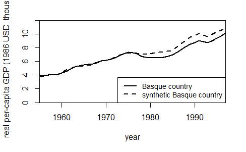

人均国内生产总值趋势：巴斯克地区与合成巴斯克地区

- 在大规模恐怖活动爆发之前（1975年），真实巴斯克与合成巴斯克的人均GDP十分接近，说明合成巴斯克地区拟合度较高；  
  二者在1975年后即开始分岔。

## 合成控制法图示

### 巴斯克地区与合成巴斯克地区的人均GDP差距

```r
gaps.plot(synth.res = synth.out,
          dataprep.res = dataprep.out,
          Ylab = "gap in real per-capita GDP
          (1986 USD, thousand)",
          Xlab = "year", Ylim = c(-1.5, 1.5),
          Main = NA)
```

## 真实巴斯克与合成巴斯克的人均GDP差距

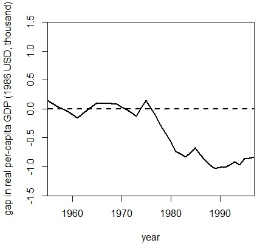

- 1980-1990年代,真实巴斯克的人均GDP比合成巴斯克低约10%， 即巴斯克恐怖活动的经济成本是损失了约10%的人均GDP。

## 安慰剂检验

```r
data <- read.csv(file = "gaps.csv")
plot(data$x, data$y1, type = 'l',
ylab = "gap in real per-capita GDP (1986 USD, thousand)",
xlab = "year", ylim = c(-1.5, 1.5), lwd = 2, main = NA)
abline(h = 0, lty = 2, lwd = 2, v = 1970, lty = 3)
text(x = 1963, y = -1.25, labels = "Terrorism Onset →", cex = 0.65)
lines(data$x, data$y2, type = 'l', col = "gray")
lines(data$x, data$y3, type = 'l', col = "gray")
lines(data$x, data$y4, type = 'l', col = "gray")
lines(data$x, data$y6, type = 'l', col = "gray")
lines(data$x, data$y7, type = 'l', col = "gray")
lines(data$x, data$y8, type = 'l', col = "gray")
lines(data$x, data$y9, type = 'l', col = "gray")
lines(data$x, data$y10, type = 'l', col = "gray")
lines(data$x, data$y11, type = 'l', col = "gray")
lines(data$x, data$y13, type = 'l', col = "gray")
lines(data$x, data$y15, type = 'l', col = "gray")
lines(data$x, data$y16, type = 'l', col = "gray")
lines(data$x, data$y18, type = 'l', col = "gray")
```

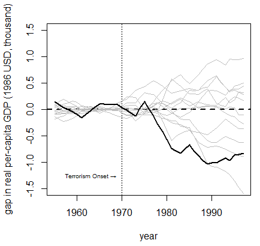

- 与其他地区的安慰剂效应相比，巴斯克地区的（负）处理效果显得特别大，进一步说明了合成控制法所估计的恐怖主义冲突对经济的影响不是偶然因素所驱动。

## 疫情区域特征分析小结与展望

- 运用`nCov2019`程序包获取疫情数据
- 运用`ggplot2`、`maps`等程序包实现疫情数据可视化
- 介绍了合成控制法及在R中的实现
- 利用疫情数据进行疫情区域特征分析
- 利用合成控制法估计疫情下不同城市的政策因果效应
- 结合疫情区域特征数据进行快速风险评估

## 参考文献

- [1]王学钦团队报告：从病例数据对比分析影响温州与深圳疫情的特征
- [2]Tianzhi Wu, ijin Ge, Guangchuang Yu, Erqiang Hu. Open-source analytics tools for studying the COVID-19 coronavirus outbreak
- [3]Abadie A, Gardeazabal J (2003).The Economic Costs of Conflict: A Case Study of the Basque Country.[J] American Economic Review, 93(1), 112–132.
- [4]Abadie, Alberto, Alexis Diamond and Jens Hainmueller. “Synth: An R Package for Synthetic Control Methods in Comparative Case Studies.” Journal of Statistical Software, June 2011, Volume 42, Issue 13, p.1-17.